# Data viz basics with R and ggplot2

### Add aesthetic mapping

That didn’t do anything so far. We’ve only specified the dataset to get the plotting data from, without saying which columns of the dataset will be mapped to which graphical elements.

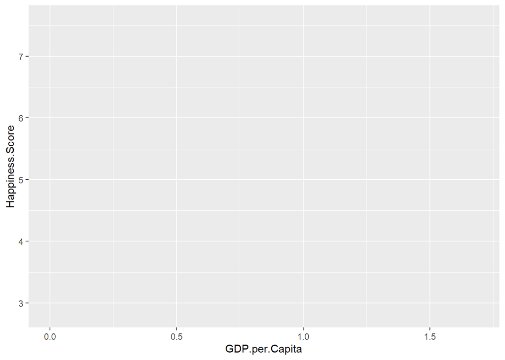

```r
ggplot(data = WHR, aes(x = GDP.per.Capita, y = Happiness.Score))
```

### Add a geom layer

Once we add the *x* and *y* mappings, we now can see the two axes and coordinate system, which is already set to the range of each variable, but no data yet. We haven’t added any `geom` layers.

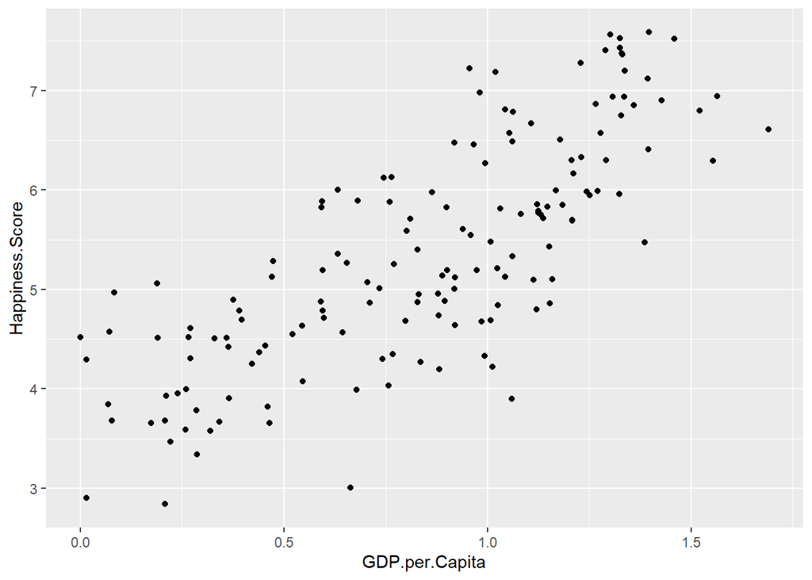

```r
ggplot(data = WHR, aes(x = GDP.per.Capita, y = Happiness.Score)) + geom_point()
```

By adding a `geom_point()` layer to the plotting code, we have now made a scatterplot!

> Notice we use `+` to add each new piece of the plotting code.

### Modifying the plot: changing the geom

We can modify the plot in many ways. One way is by changing the `geom`. This will plot the same data but using a different type of plot. For example we might want to connect data points with lines instead of drawing them as separate points. For that we will replace `geom_point()` with `geom_line()`.

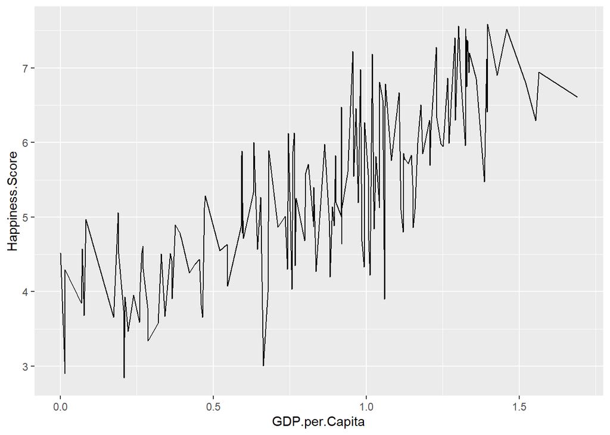

```r
ggplot(data = WHR, aes(x = GDP.per.Capita, y = Happiness.Score)) + geom_line()
```

The `geom_line` doesn’t make a lot of sense in this case but it is great for time series data.

We can add multiple `geom`s if we want. For instance, we can plot a smoothing trendline (`geom_smooth()`) overlaid on the scatterplot.

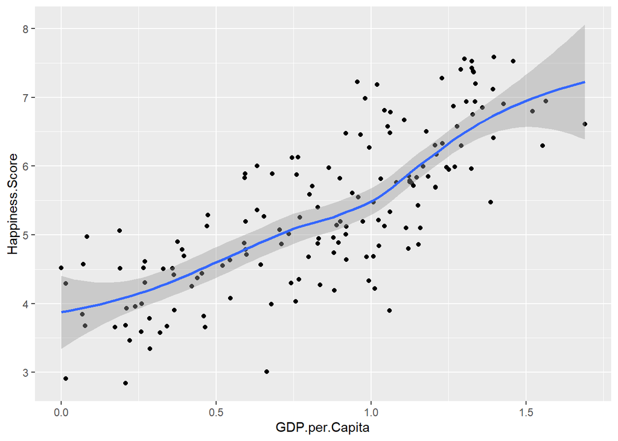

```r
ggplot(data = WHR, aes(x = GDP.per.Capita, y = Happiness.Score)) +
  geom_point() +
  geom_smooth()
```

Now we have a point plot with a trendline overlaid on top. The `geom`s are drawn in the order they are added to the plot.

> Notice I have put each piece on its own line. This makes the code much easier to read especially if you are making a complex plot with dozens of lines of code.

By default, the `geom_smooth()` plots a locally weighted regression with standard error as a shaded area. We can change the type of trend to a linear trend by specifying `method = lm` as an argument, and get rid of the standard error shading by specifying `se = FALSE`.

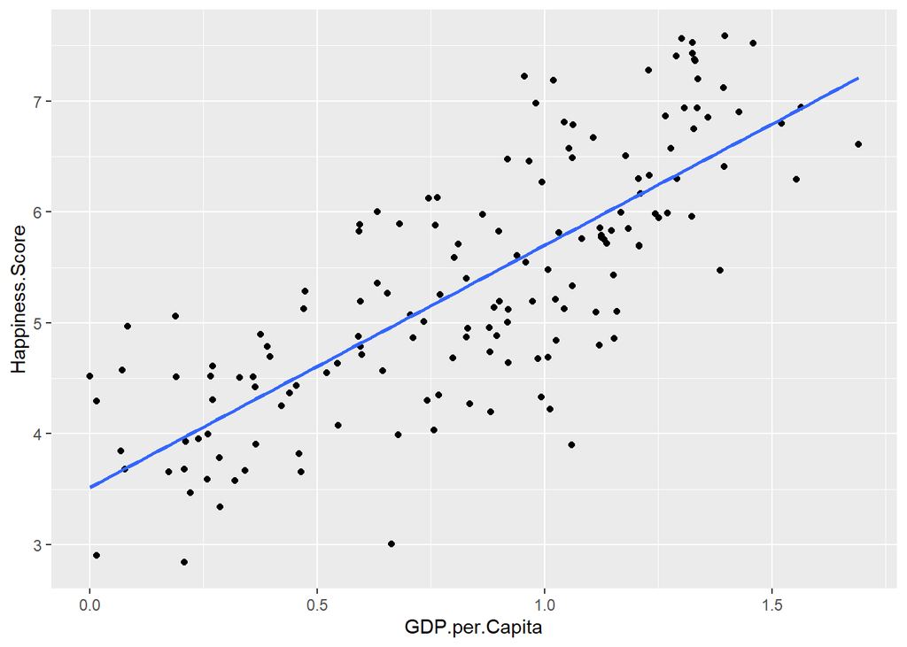

```r
ggplot(data = WHR, aes(x = GDP.per.Capita, y = Happiness.Score)) +
  geom_point() +
  geom_smooth(method = lm, se = FALSE)
```

### Modifying the plot: changing the aes

If we add to or change the `aes` arguments, we will modify or change what data are used to plot. For example let’s add a `color` aesthetic to the point plot to color each country’s point by continent.

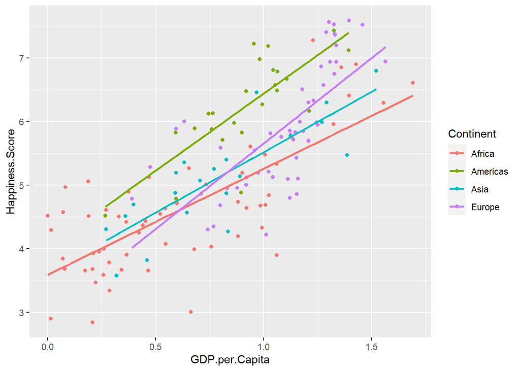

```r
ggplot(data = WHR, aes(x = GDP.per.Capita, y = Happiness.Score, color = Continent)) +
  geom_point() +
  geom_smooth(method = lm, se = FALSE)
```

We automatically get a legend. However, this also automatically groups the trendline by region as well.

If we have multiple `geom`s, we can add an `aes` argument to a single `geom`. For example if we want the points to be colored by continent but a single overall trendline, we add `aes(color = Continent)` inside `geom_point()`.

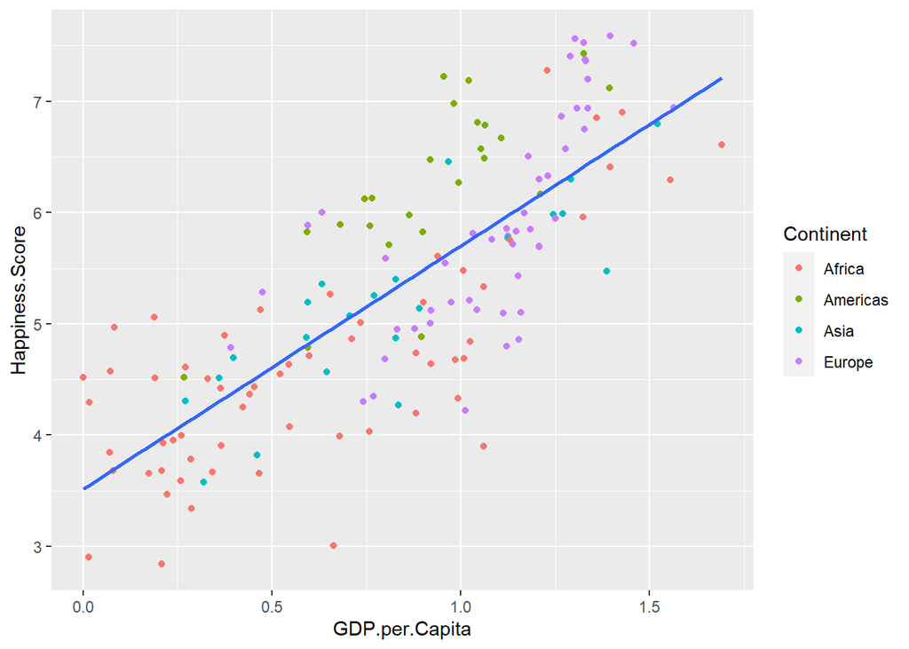

```r
ggplot(data = WHR, aes(x = GDP.per.Capita, y = Happiness.Score)) +
  geom_point(aes(color = Continent)) +
  geom_smooth(method = lm, se = FALSE)
```

If we add arguments to the `geom`s outside `aes()`, it will modify their appearance without mapping back to the data. For example we might want bigger points, and we might want the trendline to be black. That is not mapping back to any part of the original data, it is just a modification to the look of the plot.

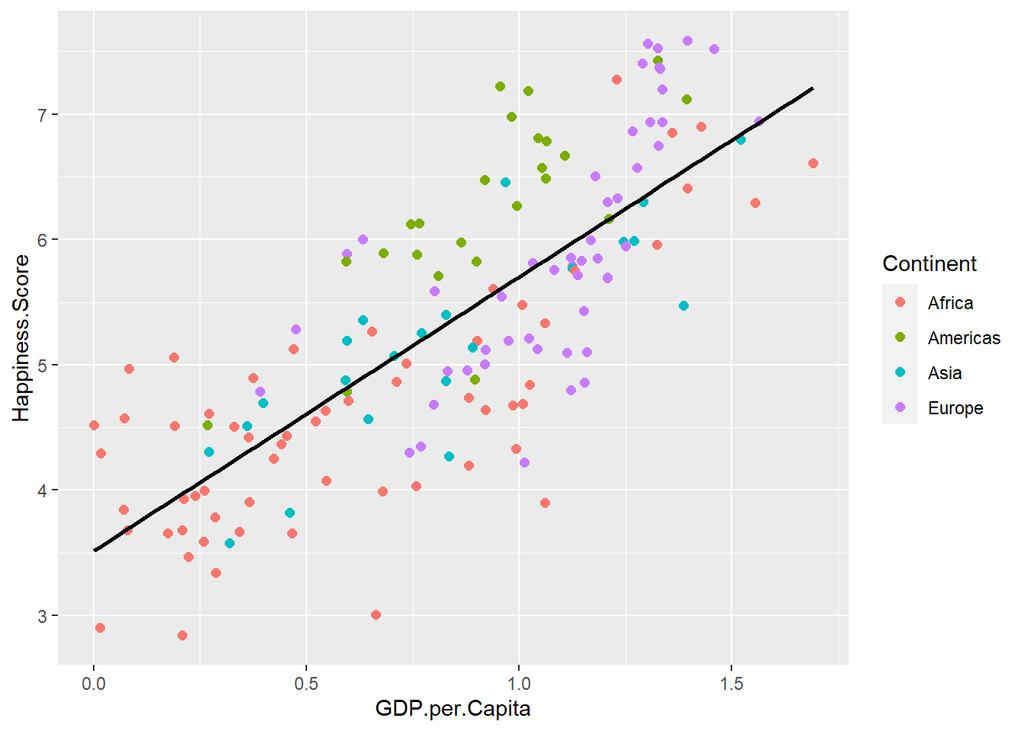

```r
ggplot(data = WHR, aes(x = GDP.per.Capita, y = Happiness.Score)) +
  geom_point(aes(color = Continent), size = 2) +
  geom_smooth(method = lm, se = FALSE, color = 'black')
```

> The default for `geom_point` is `size = 1`.

### Modifying the plot: changing the theme

We can add a theme to the plot. Themes change the overall look of the plot.

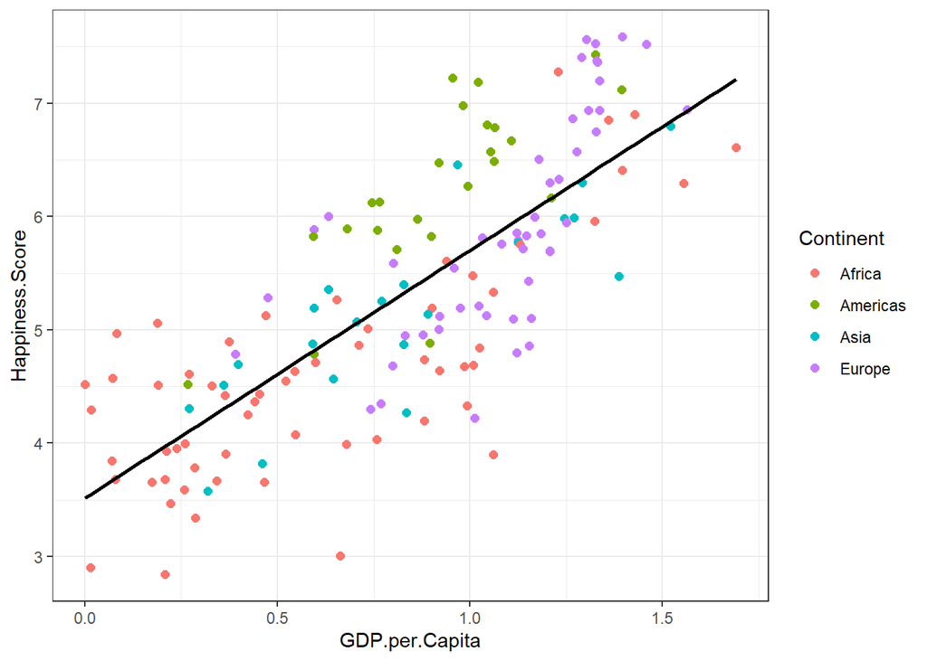

```r
happy_gdp_plot <- ggplot(data = WHR, aes(x = GDP.per.Capita, y = Happiness.Score)) +
  geom_point(aes(color = Continent), size = 2) +
  geom_smooth(method = lm, se = FALSE, color = 'black')

happy_gdp_plot + theme_bw()
```

The `theme_bw()` function changes the default theme to a black-and-white theme.

> Note that here I demonstrate that we can assign the result of `ggplot()` to an object, in this case `happy_gdp_plot`. It does not print the plot yet. Then when I type `happy_gdp_plot` again and add a theme to it, without assigning it to an object, it prints.

You can set a global theme for all plots created in your current R session by using `theme_set()`. I will do this now so we don’t have to look at the ugly gray default theme!

```r
theme_set(theme_bw())
```

We can use the `theme()` function to add specific theme arguments to a plot. For instance we can move the legend to the bottom of the plot, remove the gridlines, and change the appearance of different text elements.

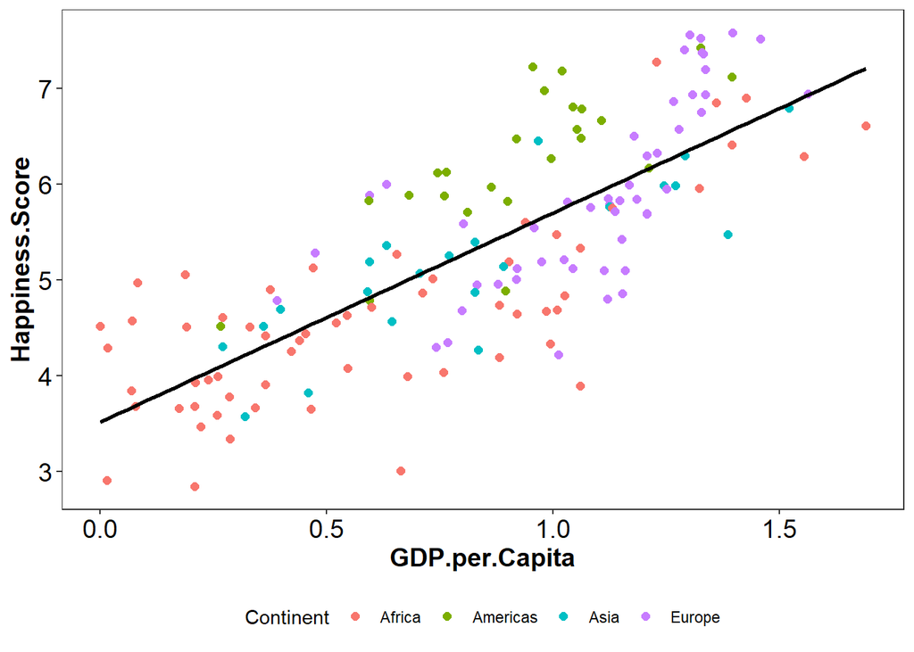

```r
happy_gdp_plot <- happy_gdp_plot +
  theme(panel.grid = element_blank(),
        legend.position = 'bottom',
        axis.text = element_text(color = 'black', size = 14),
        axis.title = element_text(face = 'bold', size = 14))

happy_gdp_plot
```

### Modifying the plot: changing scales

Scales can be used to modify the ways in which the data are mapped to the graphics appearing on the plot. For example, you can add scales to a plot to modify the range, breaks, and labels of the *x* and *y* axes, or the color palette used to color the points. You can optionally add a scale for each `aes` mapping in your plot.

Here I will add scales for the `x`, `y`, and `color` aesthetics one at a time.

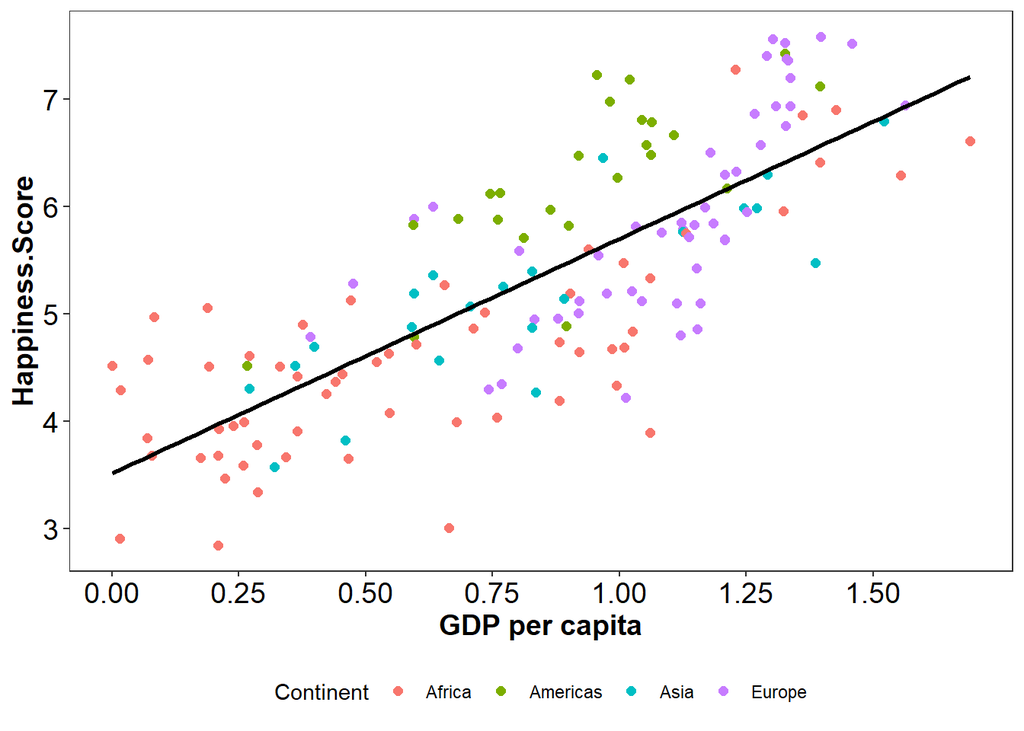

```r
happy_gdp_plot +
  scale_x_continuous(name = 'GDP per capita', breaks = c(0, 0.25, 0.5, 0.75, 1, 1.25, 1.5))
```

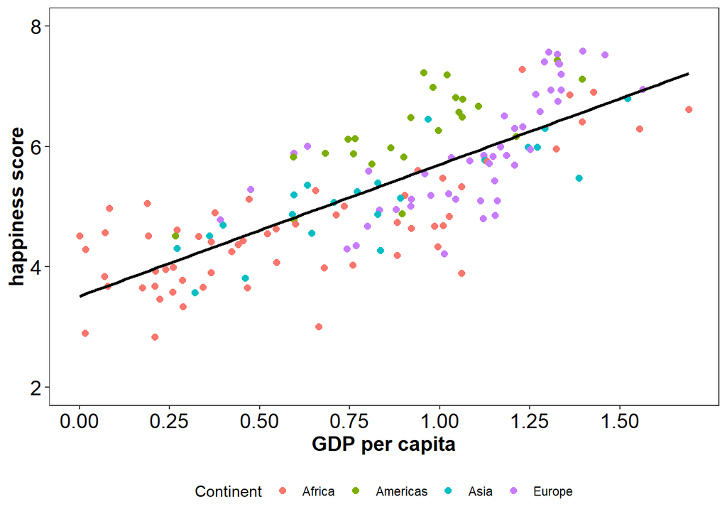

```r
happy_gdp_plot +
  scale_x_continuous(name = 'GDP per capita', breaks = c(0, 0.25, 0.5, 0.75, 1, 1.25, 1.5)) +
  scale_y_continuous(name = 'happiness score', limits = c(2, 8))
```

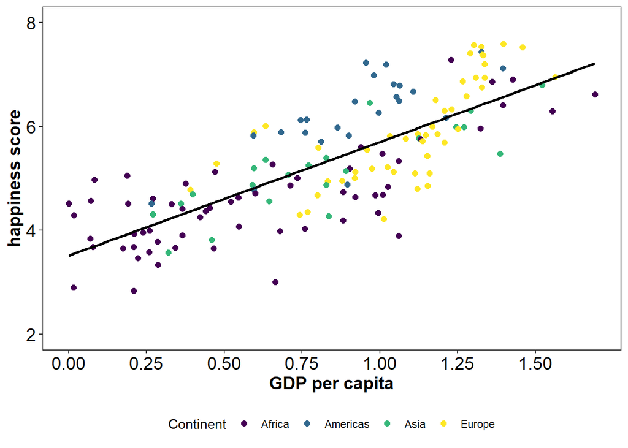

```r
happy_gdp_plot +
  scale_x_continuous(name = 'GDP per capita', breaks = c(0, 0.25, 0.5, 0.75, 1, 1.25, 1.5)) +
  scale_y_continuous(name = 'happiness score', limits = c(2, 8)) +
  scale_color_viridis_d()
```

> `scale_color_viridis_d()` is a color scheme that can be distinguished by colorblind people.

## Boxplots

Another common plot type is the boxplot. We can plot the happiness score data on the y-axis again, but instead of a continuous x-axis, we will use continent as a discrete or categorical x-axis. A boxplot is a useful way to visualize distributions grouped by discrete categories. The function we need is `geom_boxplot()`.

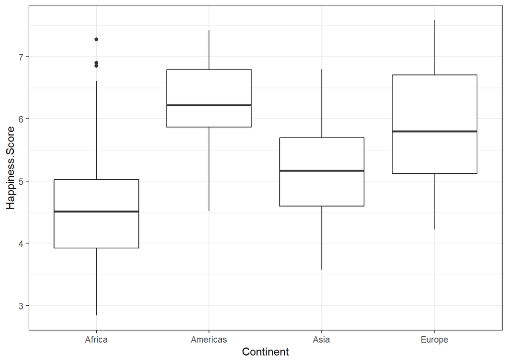

```r
ggplot(data = WHR, aes(x = Continent, y = Happiness.Score)) +
  geom_boxplot()
```

We can modify the boxplots in different ways. First let’s fill them with a nice color, change the black outlines to a dark gray, and make all the lines thicker (`size = 1.5` where the default is 1).

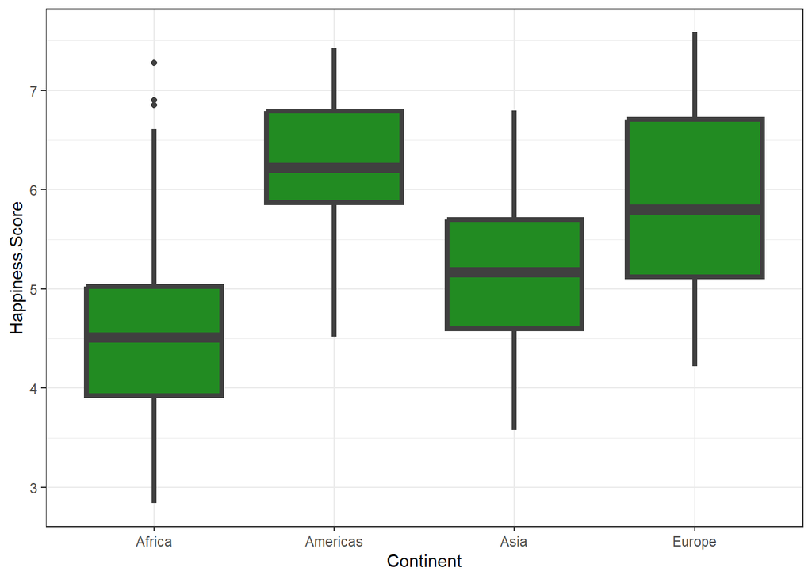

```r
ggplot(data = WHR, aes(x = Continent, y = Happiness.Score)) +
  geom_boxplot(fill = 'forestgreen', color = 'gray25', size = 1.5)
```

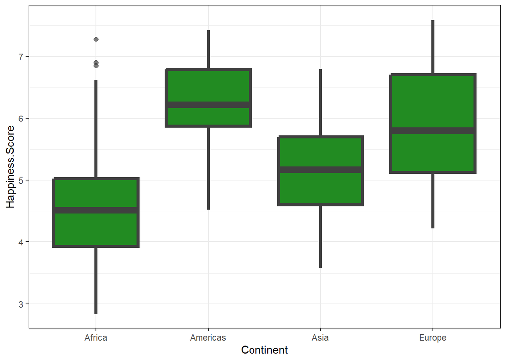

```r
ggplot(data = WHR, aes(x = Continent, y = Happiness.Score)) +
  geom_boxplot(fill = 'forestgreen', color = 'gray25', size = 1.5,
               outlier.size = 2, outlier.alpha = 0.7)
```

## Histograms and density plots

Let’s switch to a different dataset: the `cereal` dataset. Let’s look at the distribution of grams of sugar per serving in each type of breakfast cereal (the `sugars` column). We only have one variable now so we only need to map an `x` aesthetic. The `y` value will be computed internally by `ggplot()`.

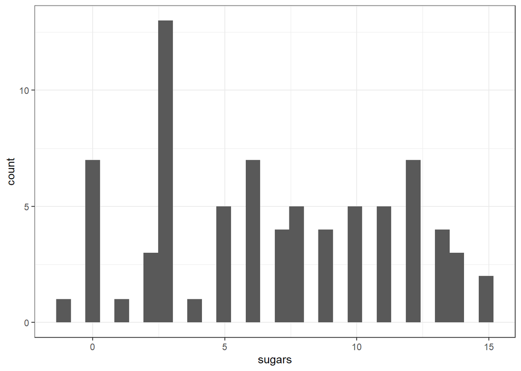

```r
ggplot(data = cereal, aes(x = sugars)) +
  geom_histogram()
```

We can modify this histogram in many ways. For instance let’s reduce the number of bins to 10 from the default value of 30 to get a histogram with fewer gaps.

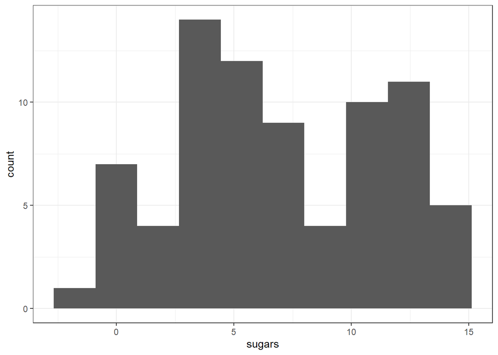

```r
ggplot(data = cereal, aes(x = sugars)) +
  geom_histogram(bins = 10)
```

By default, the y axis has a small gap between the highest and lowest value and the edge of the plot. That is great for scatterplots but doesn’t look good for histograms. We can change this by adding a y axis scale with an `expand` argument.

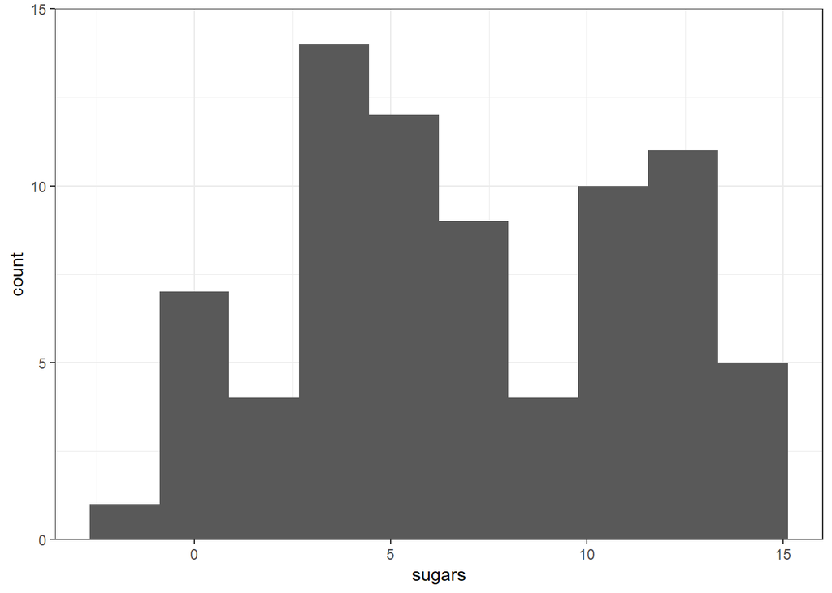

```r
ggplot(data = cereal, aes(x = sugars)) +
  geom_histogram(bins = 10) +
  scale_y_continuous(expand = expansion(add = c(0, 1)))
```

I used `expansion(add = c(0, 1))` to indicate I wanted to add 0 units of padding at the low end of the axis, and 1 unit at the high end.

Now I am going to change the fill color of the histogram bars, and add a title and subtitle to the plot with the `ggtitle()` function.

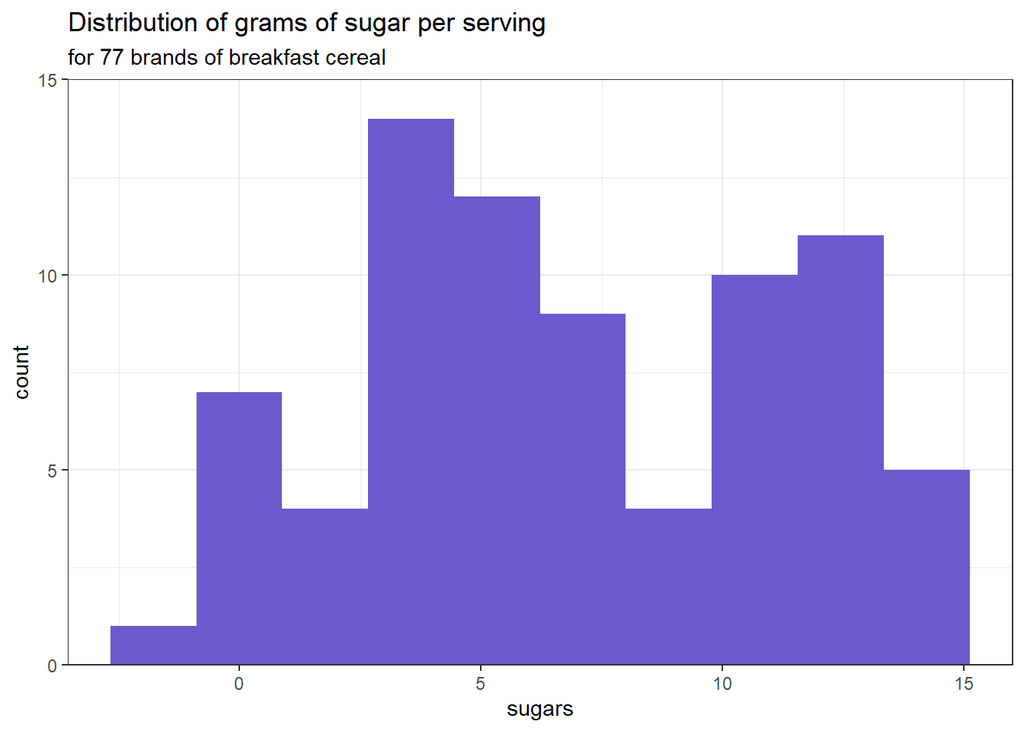

```r
sugar_hist <- ggplot(data = cereal, aes(x = sugars)) +
  geom_histogram(bins = 10, fill = 'slateblue') +
  scale_y_continuous(expand = expansion(add = c(0, 1))) +
  ggtitle('Distribution of grams of sugar per serving', 'for 77 brands of breakfast cereal')

sugar_hist
```

Finally we can use the `labs()` function to change the label on one or more axes without having to specify the entire scale.

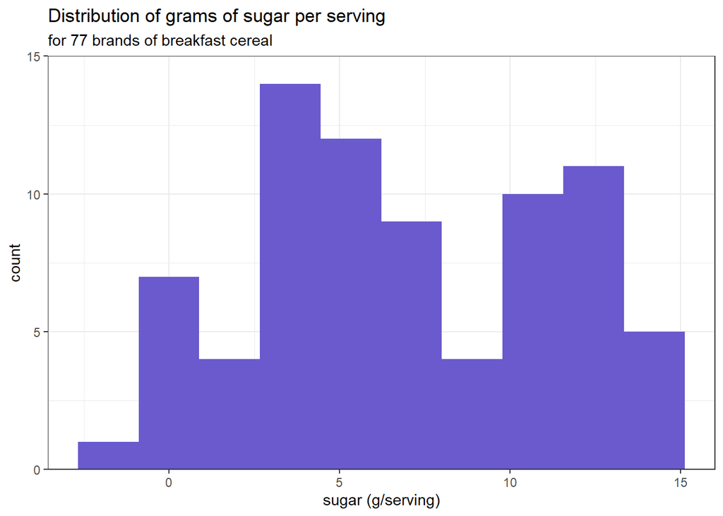

```r
sugar_hist +
  labs(x = 'sugar (g/serving)')
```

An alternative to the histogram is a smoothed kernel density plot. Let’s use the `calories` variable for that.

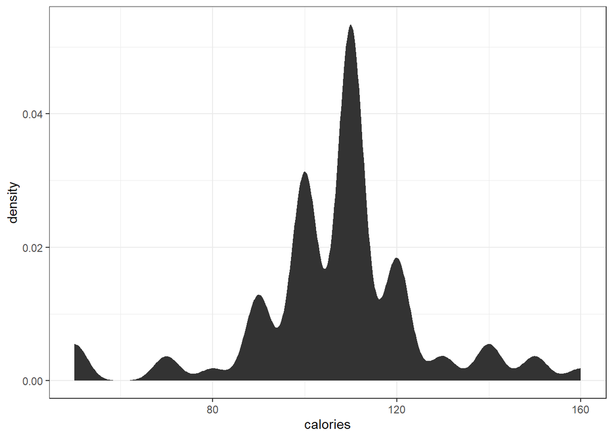

```r
ggplot(data = cereal, aes(x = calories)) +
  stat_density()
```

> Notice we used `stat_density()`. In general, functions beginning `stat_*()` will compute some summary statistic or function based on the data and plot it.

To get a less squiggly density plot, we can tweak the bandwidth parameter (the `adjust` argument) of the density smoothing algorithm. The higher the `adjust` argument is set (the default is 1), the smoother the curve.

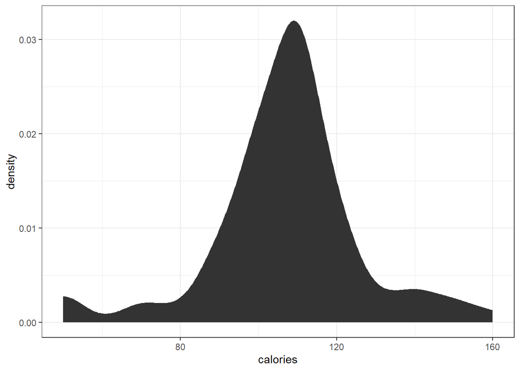

```r
ggplot(data = cereal, aes(x = calories)) +
  stat_density(adjust = 2)
```

If we just want a line instead of a filled shape we can specify the `geom` to be used for `stat_density()`. The default is `'polygon'` but we can change it to `'line'`.

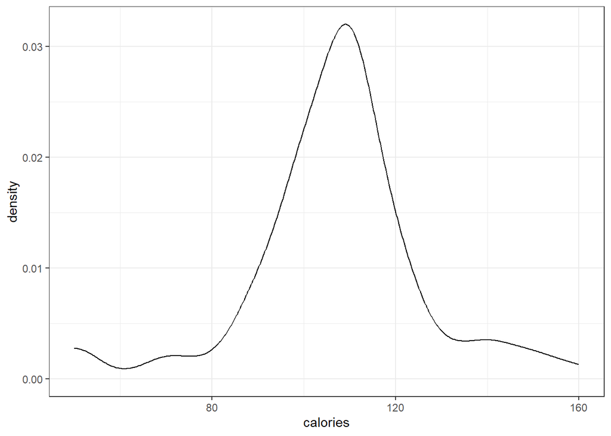

```r
ggplot(data = cereal, aes(x = calories)) +
  stat_density(adjust = 2, geom = 'line')
```

Let’s improve the look of this plot by getting rid of the gaps on either end of the x-axis and below the 0 line on the y-axis, changing the width and color of the line, and adding a title for the plot and x-axis.

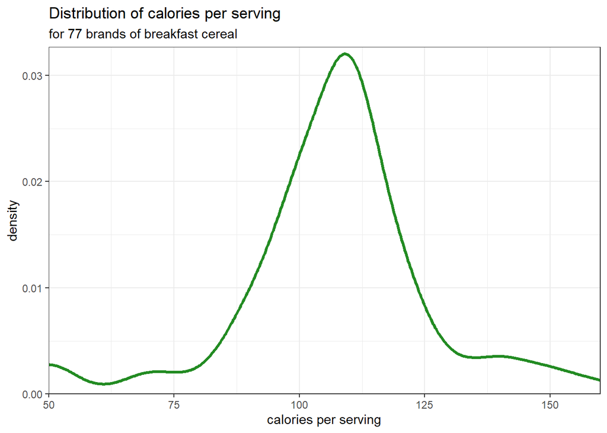

```r
ggplot(data = cereal, aes(x = calories)) +
  stat_density(adjust = 2, geom = 'line', linewidth = 1.2, color = 'forestgreen') +
  scale_y_continuous(expand = expansion(mult = c(0, 0.02))) +
  scale_x_continuous(expand = expansion(mult = c(0, 0)), name = 'calories per serving') +
  ggtitle('Distribution of calories per serving', 'for 77 brands of breakfast cereal')
```

## Facets

One of the most useful features of **ggplot2** is the ability to easily create multiple subplots, one for each subgroup of a dataset. Let’s take a subset of the `olympics` dataset to compare the athletics performance of some of the best track-and-field nations over the years: the USA, Great Britain (GBR), the Soviet Union (URS), and Jamaica (JAM).

```r
olympics_best <- subset(olympics, Country %in% c('USA', 'GBR', 'URS', 'JAM'))
```

Make a bar plot of the three types of medals awarded. The `geom_bar()` function can be used to compute counts within each category.

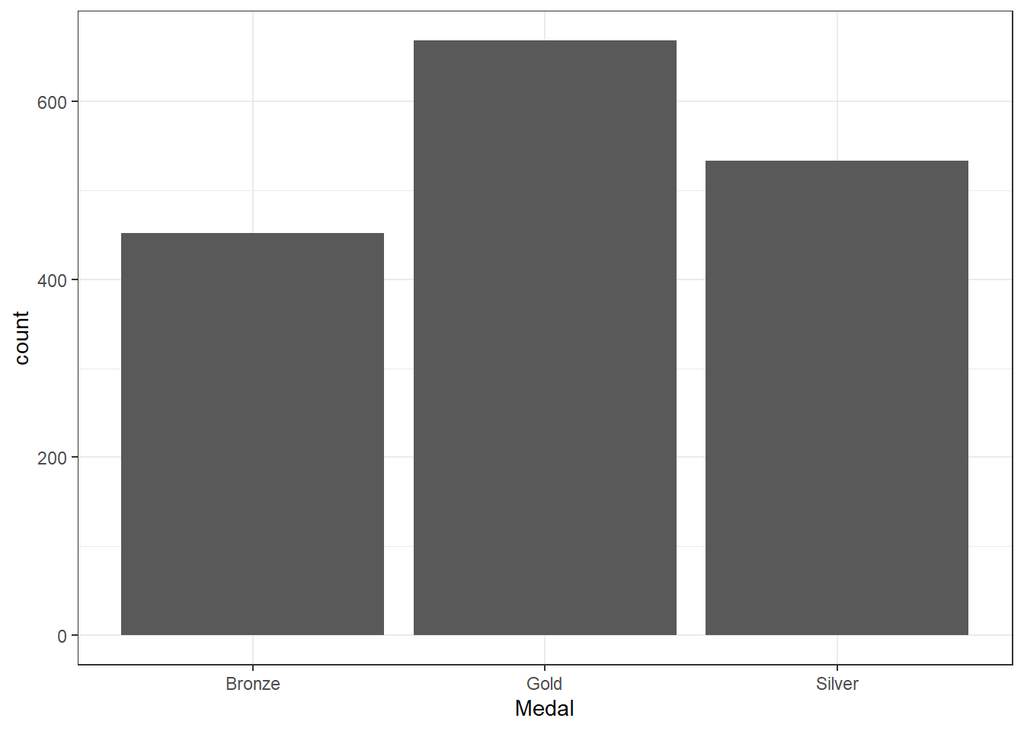

```r
ggplot(olympics_best, aes(x = Medal)) +
  geom_bar(stat = 'count')
```

To make this plot more informative, let’s split it up by country. We use the `facet_wrap()` function with a one-sided formula `~ Country` to make a separate plot for each country.

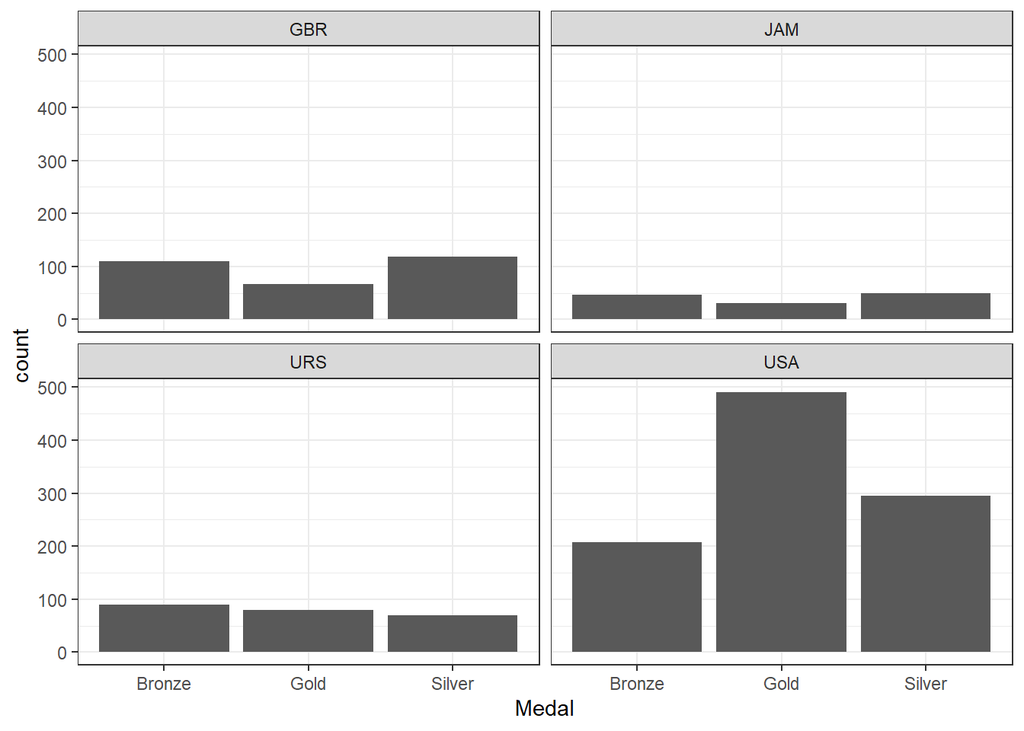

```r
ggplot(olympics_best, aes(x = Medal)) +
  geom_bar(stat = 'count') +
  facet_wrap(~ Country)
```

By default, all the facets have the same y-axis limits. We can make each facet have its own limits by setting `scales = 'free_y'`.

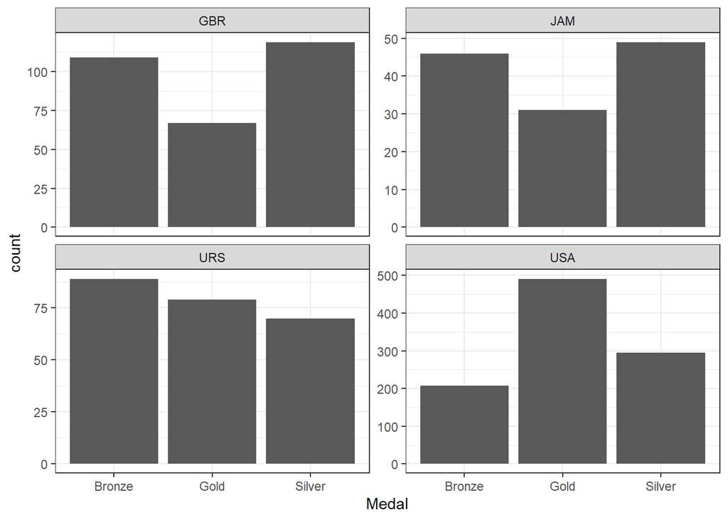

```r
ggplot(olympics_best, aes(x = Medal)) +
  geom_bar(stat = 'count') +
  facet_wrap(~ Country, scales = 'free_y')
```

We can facet in both directions using `facet_grid()` with a two-sided formula. For instance we can show the medal tally for each country by gender in a 4x2 plot.